# Overlapping happiness: An analysis of the HappyDB dataset

## Overview and Background

This is a report based off the data in the HappyDB dataset: https://github.com/megagonlabs/HappyDB

The HappyDB dataset is a collection of crowd sourced happy moments. On Amazon Mechanical Turk, participants were asked to recall three happy moments.

From this information, we can glean some insight into the perception of happiness. Happiness itself is nebulous and hard to quantify -- doubly so considering the rather open ended nature of the question posed to the participants. However, there are clearly several different types of happiness. In this review, we would like to see:

1) What types of happiness is most common? 2) What is most representative for each category of happiness? 3) Are there significant overlaps between catetgories of happiness? Which types of happiness are most similar?

```python
!pip install wordcloud
```

```python
# libraries
import sys
import platform
from collections import Counter

import pandas as pd
import numpy as np

# stop words processing
import nltk
from nltk.corpus import stopwords
from nltk.tokenize import word_tokenize
from nltk.stem import WordNetLemmatizer

# analysis
import sklearn
from sklearn.feature_extraction.text import TfidfVectorizer
from sklearn.metrics.pairwise import cosine_similarity

# graphs
import matplotlib.pyplot as plt
from wordcloud import WordCloud
import seaborn as sns
```

### Environment Version

```python
# system and python versions
print(sys.version)
print(platform.python_version())
```

```
3.11.4 (main, Jul  5 2023, 08:54:11) [Clang 14.0.6 ]
3.11.4
```

## Data import

The main dataset we use is the cleaned_hm.csv dataset (this has already been cleaned for us)

```python
df = pd.read_csv('../data/happydb/data/cleaned_hm.csv')
```

```python
# sample display of our data
df.head(5)
```

|  | hmid | wid | reflection_period | original_hm | cleaned_hm | modified | num_sentence | ground_truth_category | predicted_category |
| --- | --- | --- | --- | --- | --- | --- | --- | --- | --- |
| 0 | 27673 | 2053 | 24h | I went on a successful date with someone I fel... | I went on a successful date with someone I fel... | True | 1 | NaN | affection |
| 1 | 27674 | 2 | 24h | I was happy when my son got 90% marks in his e... | I was happy when my son got 90% marks in his e... | True | 1 | NaN | affection |
| 2 | 27675 | 1936 | 24h | I went to the gym this morning and did yoga. | I went to the gym this morning and did yoga. | True | 1 | NaN | exercise |
| 3 | 27676 | 206 | 24h | We had a serious talk with some friends of our... | We had a serious talk with some friends of our... | True | 2 | bonding | bonding |
| 4 | 27677 | 6227 | 24h | I went with grandchildren to butterfly display... | I went with grandchildren to butterfly display... | True | 1 | NaN | affection |

## Removing stop words

I created a filtered version of cleaned_hm.csv (original is stored in the data subdirectory) by removing the stop words from the cleaned_hm column.

```python
nltk.download("stopwords")
stop_words = list(stopwords.words('english'))   #179 stopwords
```

```python
# add a column to the dataframe that has stopwords removed
df["cleaned_hm_filtered"] = [[word for word in sentence.lower().split(" ") if word not in stop_words] for sentence in df["cleaned_hm"]]
```

```python
df["cleaned_hm_filtered"]
```

```
0         [went, successful, date, someone, felt, sympat...
1              [happy, son, got, 90%, marks, examination, ]
2                               [went, gym, morning, yoga.]
3         [serious, talk, friends, flaky, lately., under...
4         [went, grandchildren, butterfly, display, croh...
                                ...
100530    [husband, announced, getting, decent, bonus, q...
100531                                      [pepsi, drink.]
100532                 [cuddling, girlfriend, last, night.]
100533    [great, meeting, yesterday, work, boss, collea...
100534                       [great, workout, last, night.]
Name: cleaned_hm_filtered, Length: 100535, dtype: object
```

As seen above, the stop words have been removed from the cleaned_hm sentence.

# Question 1) What are the categories of happiness and which one is most common?

Luckily, this is the easiest question to answer since the HappyDB database has already provided the categories for us. We can just count the frequencies.

This mainly serves as an introductory question to the future analyses we are going to look at.

```python
df.groupby("predicted_category").size()
```

```
predicted_category
achievement         33993
affection           34168
bonding             10727
enjoy_the_moment    11144
exercise             1202
leisure              7458
nature               1843
dtype: int64
```

There are seven categories of happiness: 1) achievement, 2) affection, 3) bonding, 4) enjoy_the_moment, 5) exercise, 6) leisure 7) nature.

# Question 2) What makes up each type of happiness?

Is there a common theme between different types of happiness? Using our cleaned data without stopwords, we can look at if there are common words between the different categories.

This can later tell us which types of happiness may be most similar to each other!

## Metric: Words in categories of happiness

For each category of happiness, we are going to create a "bag of words". This contains the non-stopwords that are used in this category.

Having created this dataframe, we can look at the word frequencies and proportions to see which words are most associated with which category of happiness. This can be visually demonstrated with a word cloud.

Additionally, we can see which categories of happiness are most similar to which other categories of happiness by looking at how similar their "bag of words" or word clouds are. (Another way to think about this is having a vector where each dimension is a unique non-stopword and finding the cosine-similarity between each happiness category's vector).

```python
# create a dataframe that has a word cloud for each happiness category

happiness_categories = ["achievement", "affection", "bonding", "enjoy_the_moment", "exercise", "leisure", "nature"]

word_cloud = {}

for index, row in df.iterrows():
    category = row["predicted_category"]

    if category not in word_cloud: #add category to dictionary
        word_cloud[category] = []

    word_cloud[category].extend(row["cleaned_hm_filtered"])
```

## Word clouds for each category

These have been saved to the outputs folder under graphs

```python
wordcloud_achievement = WordCloud(width = 800, height = 800,
                background_color ='white',
                stopwords = stop_words,
                min_font_size = 10).generate(" ".join(word_cloud["achievement"]))

wordcloud_affection = WordCloud(width = 800, height = 800,
                background_color ='white',
                stopwords = stop_words,
                min_font_size = 10).generate(" ".join(word_cloud["affection"]))

wordcloud_bonding = WordCloud(width = 800, height = 800,
                background_color ='white',
                stopwords = stop_words,
                min_font_size = 10).generate(" ".join(word_cloud["bonding"]))

wordcloud_moment = WordCloud(width = 800, height = 800,
                background_color ='white',
                stopwords = stop_words,
                min_font_size = 10).generate(" ".join(word_cloud["enjoy_the_moment"]))

wordcloud_exercise = WordCloud(width = 800, height = 800,
                background_color ='white',
                stopwords = stop_words,
                min_font_size = 10).generate(" ".join(word_cloud["exercise"]))

wordcloud_leisure = WordCloud(width = 800, height = 800,
                background_color ='white',
                stopwords = stop_words,
                min_font_size = 10).generate(" ".join(word_cloud["leisure"]))

wordcloud_nature= WordCloud(width = 800, height = 800,
                background_color ='white',
                stopwords = stop_words,
                min_font_size = 10).generate(" ".join(word_cloud["nature"]))
```

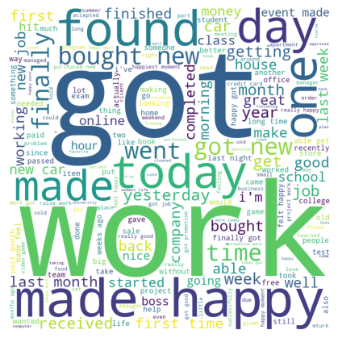

```python
plt.figure(figsize = (4,4), facecolor = None)
plt.imshow(wordcloud_achievement)
plt.axis("off")
plt.tight_layout(pad = 0)

plt.show()
```

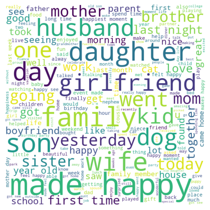

```python
plt.figure(figsize = (4,4), facecolor = None)
plt.imshow(wordcloud_affection)
plt.axis("off")
plt.tight_layout(pad = 0)

plt.show()
```

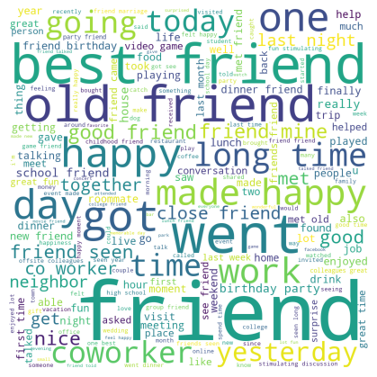

```python
plt.figure(figsize = (4,4), facecolor = None)
plt.imshow(wordcloud_bonding)
plt.axis("off")
plt.tight_layout(pad = 0)

plt.show()
```

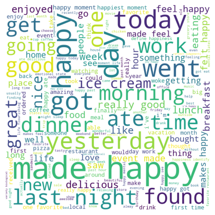

```python
plt.figure(figsize = (4,4), facecolor = None)
plt.imshow(wordcloud_moment)
plt.axis("off")
plt.tight_layout(pad = 0)

plt.show()
```

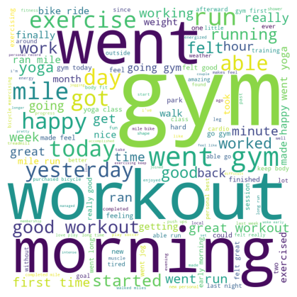

```python
plt.figure(figsize = (4,4), facecolor = None)
plt.imshow(wordcloud_exercise)
plt.axis("off")
plt.tight_layout(pad = 0)

plt.show()
```

[figure not shown]

```python
plt.figure(figsize = (4,4), facecolor = None)
plt.imshow(wordcloud_leisure)
plt.axis("off")
plt.tight_layout(pad = 0)

plt.show()
```

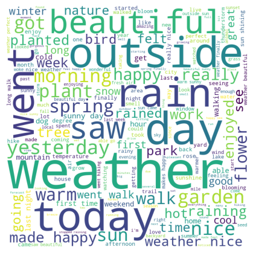

```python
plt.figure(figsize = (4,4), facecolor = None)
plt.imshow(wordcloud_nature)
plt.axis("off")
plt.tight_layout(pad = 0)

plt.show()
```

Looking at the bag of words above, we can see that "work" and "got" are important to the achievemnent category of happiness while "family" related terms are associated with affection. Looking closely at each word cloud, we can better understand what makes up each type of happiness.

# Question 3) Associations between categories of happiness? Which types of happiness are most similar?

## Vector similarities (TF-IDF using NLTK)

Although the wordclouds gave us a good visual representation of the non-stopword frequencies per categories, it does not give us great insight into the similarities or overlap between categories.

We can do this by finding the TF-IDF vectors for each happiness category and finding the cosine similarities between them (this can be visually represented with a heatmap).

Unfortunately, because the vectors are so large, the cosine-similarity takes a long time to calculate and kills the kernel each time. Because of this, we alter the method by capping max features for the vector to 50 (this being the 50 most frequently used words throughout all the corpus).

```python
#find 50 most frequently used words

word_list = []
for key in word_cloud:
    word_list.extend(word_cloud[key])

def most_common_words(words, n=50):
    word_counter = Counter(words)
    return [word for word, _ in word_counter.most_common(n)]

# most common 50
feature_words = most_common_words(word_list)
```

```python
#modify the word cloud so it only returns the most common words

word_cloud_most_common = {}

for key in word_cloud:
    word_cloud_most_common[key] = [w for w in word_cloud[key] if w in feature_words]

#lemmatize tokens
# tokens = word_tokenize(feature_words)
# lemmatizer = WordNetLemmatizer()
# tokens1 = [lemmatizer.lemmatize(token) for token in tokens1]

# for key in word_cloud_most_common:
#     word_cloud_most_common[key] = [lemmatizer.lemmatize(token) for token in word_cloud_most_common[key]]
```

```python
# tf-df vectors based on word buckets
vectorizer = TfidfVectorizer(max_features=10)

vector_fit = vectorizer.fit_transform(feature_words)
vector_achievement = vectorizer.transform(word_cloud_most_common["achievement"])
vector_affection =vectorizer.transform(word_cloud_most_common["affection"])
vector_bonding = vectorizer.transform(word_cloud_most_common["bonding"])
vector_moment = vectorizer.transform(word_cloud_most_common["enjoy_the_moment"])
vector_leisure = vectorizer.transform(word_cloud_most_common["leisure"])
vector_exercise= vectorizer.transform(word_cloud_most_common["exercise"])
vector_nature = vectorizer.transform(word_cloud_most_common["nature"])
```

```python
# this is the best way to do it, but it keeps crashing my kernel
#similarity = cosine_similarity(vector_achievement, vector_affection)
```

```python
vectorizer = TfidfVectorizer()
vectors = vectorizer.fit_transform([" ".join(word_cloud_most_common["achievement"]),
                                    " ".join(word_cloud_most_common["affection"]),
                                    " ".join(word_cloud_most_common["bonding"]),
                                   " ".join(word_cloud_most_common["enjoy_the_moment"]),
                                   " ".join(word_cloud_most_common["leisure"]),
                                    " ".join(word_cloud_most_common["exercise"]),
                                   " ".join(word_cloud_most_common["nature"])]
                                   )

# Calculate the cosine similarity between the vectors
similarity = cosine_similarity(vectors)
```

```python
# convert similarity to a dataframe
similarity_df = pd.DataFrame(similarity,
                             columns=['achievement', 'affection', 'bonding', 'moment', 'leisure', 'exercise', 'nature'],
                             index=['achievement', 'affection', 'bonding', 'moment', 'leisure', 'exercise', 'nature'])
```

```python
similarity_df
```

|  | achievement | affection | bonding | moment | leisure | exercise | nature |
| --- | --- | --- | --- | --- | --- | --- | --- |
| achievement | 1.000000 | 0.733525 | 0.468161 | 0.795397 | 0.624986 | 0.579291 | 0.657454 |
| affection | 0.733525 | 1.000000 | 0.528895 | 0.835282 | 0.635482 | 0.641963 | 0.768331 |
| bonding | 0.468161 | 0.528895 | 1.000000 | 0.508174 | 0.477925 | 0.492678 | 0.506916 |
| moment | 0.795397 | 0.835282 | 0.508174 | 1.000000 | 0.628535 | 0.650186 | 0.765510 |
| leisure | 0.624986 | 0.635482 | 0.477925 | 0.628535 | 1.000000 | 0.837950 | 0.747771 |
| exercise | 0.579291 | 0.641963 | 0.492678 | 0.650186 | 0.837950 | 1.000000 | 0.826098 |
| nature | 0.657454 | 0.768331 | 0.506916 | 0.765510 | 0.747771 | 0.826098 | 1.000000 |

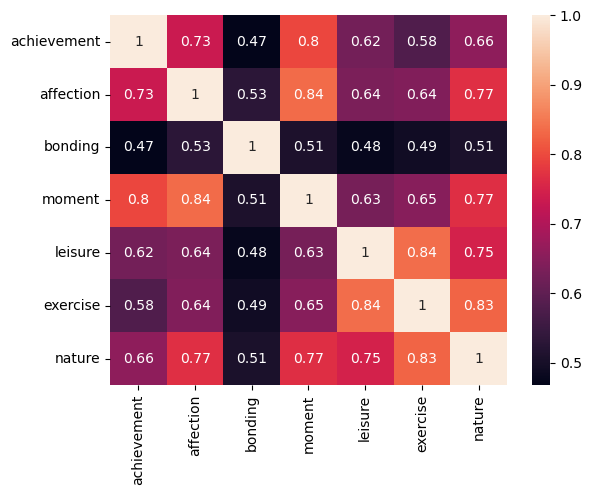

```python
# heatmap representation
sns.heatmap(similarity_df, annot=True)
```

## Conclusions

From the above vector similarities (and heatmap), we can see that the most closely similar types of happiness are "exercise" and "nature" with a score of 0.83, "leisure" and "exercise" with a score of 0.84 and "affection" and "enjoy_the_moment" with 0.84.